# Factor_Analysis_2

## Factor Analysis

#### **Load Data**

```python
from sklearn.datasets import load_iris
from sklearn.preprocessing import StandardScaler

data = load_iris()
X = StandardScaler().fit_transform(data["data"])
feature_names = data["feature_names"]
```

#### **Covariance of features**

```
[Text(0, 0.5, 'sepal length (cm)'),
```

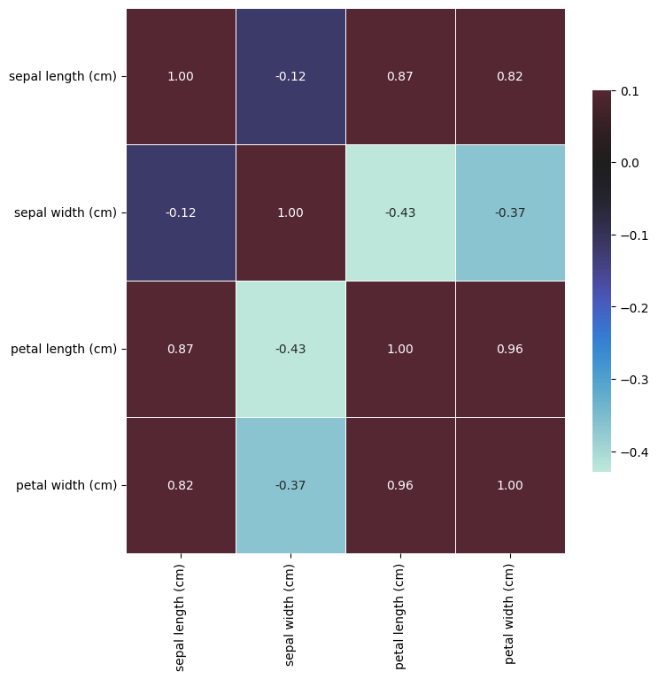

```python
import matplotlib.pyplot as plt
import seaborn as sns
import numpy as np

fig, ax = plt.subplots(figsize=(8,8))

sns.heatmap(np.corrcoef(X.T), vmax=0.1, center=0, fmt='.2f',
                square=False, linewidths=.5, annot=True, cbar_kws={"shrink": 0.7}, ax = ax)

ax.set_xticks([0.5, 1.5, 2.5, 3.5])
ax.set_xticklabels(list(feature_names), rotation=90)
ax.set_yticks([0.5, 1.5, 2.5, 3.5])
ax.set_yticklabels(list(feature_names), rotation=0)
```

#### **Train Model**

- Simplified Loadings: Rotation aims to simplify the factor structure, making high loadings higher and low loadings lower
- Orthogonal Rotation: Factors remain uncorrelated (e.g., Varimax)
- Oblique Rotation: Factors are allowed to correlate (e.g., Promax)

```python
from sklearn.decomposition import FactorAnalysis

model = FactorAnalysis(rotation="varimax", n_components=2, random_state=0)
model.fit(X)
```

```
FactorAnalysis(n_components=2, rotation='varimax')
```

#### **Analysis**

```python
# principal axes in original feature space
components = model.components_.T
components
```

```
array([[ 0.98633022, -0.05752333],
       [-0.16052385, -0.67443065],
       [ 0.90809432,  0.41726413],
       [ 0.85857475,  0.43847489]])
```

```
[Text(0, 0.5, 'sepal length (cm)'),
```

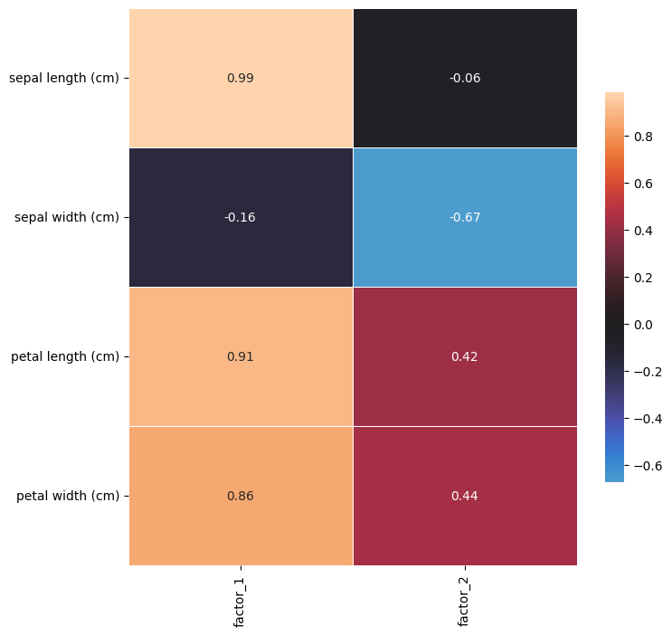

```python
vmax = np.abs(components).max()

fig, ax = plt.subplots(figsize=(8,8))

sns.heatmap(components, vmax=vmax, center=0, fmt='.2f',
                square=False, linewidths=.5, annot=True, cbar_kws={"shrink": 0.7}, ax = ax)

ax.set_xticks([0.5, 1.5])
ax.set_xticklabels(['factor_1', 'factor_2'], rotation=90)
ax.set_yticks([0.5, 1.5, 2.5, 3.5])
ax.set_yticklabels(list(feature_names), rotation=0)
```

#### **Result Interpretation**

- Factor loadings represent the correlations between the observed variables (y-axis) and the latent factors (x-axis)
- **High Loadings**, observed variables and factors have strong association (typically >0.4 or < -0.4)
- **Sign of Loadings**, the sign (positive or negative) indicates the direction of the relationship

#### **Interpretation**

- **Interpreting Factors**, a factor can be interpreted by looking at which observed variables have high loadings on it
- sepal length, petal length, and petal width have high loadings with factor_1, which may represent flower volumn
- sepal width have high loading with factor_2, which may represent sepal volumn

[figure not shown]

#### **Communalities**

- Indicate the proportion of each observed variable’s variance that can be explained by the factors
- $0.986^{2} + (-0.06)^{2} = 0.976$
- **High Communalities**, sepal length, petal length, and petal width have communality above 0.925, suggesting it is well-represented by the two factors
- **Moderate Communality**, sepal width has low comunalities, suggesting they are moderately well-represented by the two factors

```python
(components**2).sum(axis=1)
```

```
array([0.97615624, 0.4806246 , 0.99874464, 0.92941082])
```

#### **Reference**

- [Sklearn](https://scikit-learn.org/stable/auto_examples/decomposition/plot_varimax_fa.html)
- [A PRACTICAL INTRODUCTION TO FACTOR ANALYSIS: EXPLORATORY FACTOR ANALYSIS](https://stats.oarc.ucla.edu/spss/seminars/introduction-to-factor-analysis/a-practical-introduction-to-factor-analysis/)